# STAT 428: Final Project

Akshay Mahesh (mahesh4), Max Su (maxsu2), Adam Zhang(ajzhang2), Nicholas Costello (nicoste2), Kasi Manikumar (manikum2)

Due Week 14 Saturday, December 1 by 11.59 PM on Compass

# Abstract

We analyzed this magic trick to calculate the best parameters (card value type and starting point) for the Kruskal’s Count card trick to optimize for the highest chance of success. We used a sample of 100 numbers selected by distinct humans from 1 to 10 to compute likelihood estimators for the support of human_distribution PMF for starting point generation and one dimensional optimization. These results suggest that for the magician to have the highest probability of success with the trick, they should give face card’s the value of 1 or 2. Furthermore, we ran one and two dimensional optimization methods on the mean card values and card deck sample size to see parameters the maximize the probability of success for the trick.

# Introduction

Kruskal’s Count is a mathematical magic card trick that we will optimize for the highest chances of success given two parameters: the royal card count value (Jack, Queen, King) and the number the magician should pick for the best chance of success of performing this trick with a non-robotic victim .

## Card Trick

The magician lays out 52 cards face up like so:

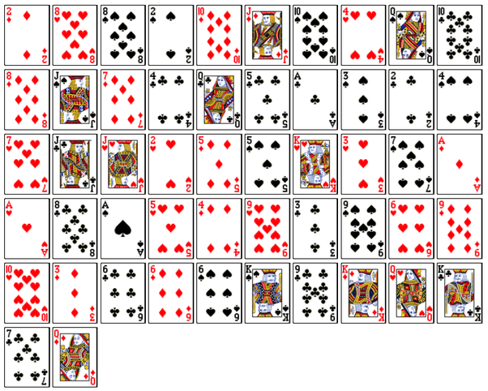

They then ask their victim to choose a number 1-10. The number they pick corresponds to the first card they choose in the top row. The value of this card is the number of cards they must count before finding their next card in their chain. Whatever card they land on is their new number and the counting process repeats. The victim continues this pattern until they reach their *key card*. The key card is the last card of their chain before they run out of cards. Face cards are given a certain value, say for instance 5.

Before the victim chooses a number, the magician slyly starts their own chain in their head that starts from the first card on the table. This chain follows the same process as the victim’s and whatever card ends up being their *key card* will be used to predict the final card the victim will land on.

**Example:** The magician starts a chain in their head based on the first card: 2 of diamonds. The full chain is: **2(D) -> 8(S) -> 8(D) -> 2(C) -> 7(H) -> 3(H) -> A(H) -> 8(C) -> 9(D) -> Q(H)** The victim chooses the number 7. The 7th card in the top row is 10 of spades. The magician then magically predicts the victim will finish on the queen of hearts. The victim’s full chain is: **10(S) -> A(C) -> 3(S) -> 7(H) -> 3(H) -> A(H) -> 8(C) -> 9(D) -> Q(H)** The chain ends on the queen of hearts since the victim runs out of cards.

As you can see from the example the magician would be correct! To the victim, they “randomly” chose the final card based on the victims random number, and thus the victim is surprised and entertained by the trick. However, diving deeper into this trick we will find there is actually a very high probability of correctly guessing the final card in the sequence and certain factors can even be altered to increase this chance further.

## Initial Data Exploration

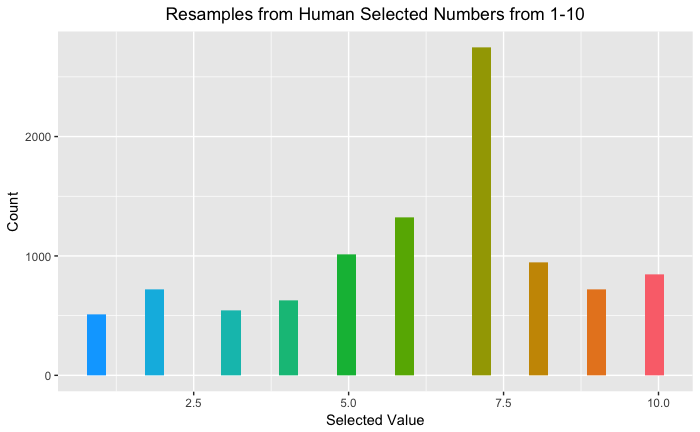

## Motivation and Problem of Interest

Given a random deck, and setting the values of our face value cards (King, Queen, Jack) to five, we arrive at a success rate of ~84% [Grime]. The motivation of our simulation is see if we can further optimize our success by modifying the mean card value, the number of cards in the deck, or both. We define the *mean card value* as the average of each card’s numeric value. We manually define the values of Jack, Queen, and King face cards.

# Methods

## Random Number Generation

First we will start by optimizing the mean card value. We fix the sample card deck size to a standard 52 card deck.

# Human Distribution Function

The “random” way that humans select a number 1 to 10 is for some reason non-uniform, and we wanted to factor this into our simulation to obtain results closest to the real world. We used a sample of 100 numbers selected by distinct humans from 1 to 10 to compute likelihood estimators for the support of human_distribution PMF. Next, we mapped distinct ranges of it’s support to distinct values in the support of our estimated PMF function. The ranges were determined by the likelihood estimators. This allows us to transform a sample from a random uniform distribution to a sample from our estimated human_distribution, and allows us to create a simulation that is closer to a real-life run of this magic trick.

```r
rhuman <- function(n){
  setwd('.')
  # Data.csv is the data of random individuals when asked to pick a number 1-10
  data = as.vector(read.csv(file="data.csv",check.names=FALSE, header=FALSE))
  estimators = numeric(10)
  for(i in 1:10){
    estimators[i] = sum(data <= i) / length(data)
  }
  estimators = c(0, estimators)
  sample = c()
  for(i in 1:n){
    x = runif(n = 1, min = 0, max = 1)
    sample = c(sum(estimators < x),sample)
  }
  return(sample)
}
```

# Card Generation and Sampling Functions

We sample from a deck of cards without replacement and create helper functions to manage card values for the simulation.

```r
ranks <- c("A",2:10,"J","Q","K")
cards = paste(rep(ranks, 4), c("H","D","S","C"))
# Create a randomized deck of cards.
create_shuffled_deck <- function() {
  sample(cards, 52)
}
# Create a rank value hashmap.
create_rank_value_map <- function(jack_value, queen_value, king_value) {
  hashmap(ranks, c(c(1:10), jack_value, queen_value, king_value))
}
# Function to get the value of the card.
card_value <- function(card, rv_map) {
  rank <- unlist(strsplit(card, " "))[1] # "A H" -> "A"
  rv_map[[rank]]
}
```

# Kruskal Simulation Function

Calculates the key card (perhaps the last card in the deck) which is not followed by enough cards to get to another one. Given an initital deck, a rank value map, and the initial number from 1-10.

```r
calc_key_card <- function(deck, rv_map, start_idx) {
  curr_card <- deck[start_idx]
  index <- start_idx

  while(index + card_value(curr_card, rv_map) <= 52) {
    index <- index + card_value(curr_card, rv_map)
    curr_card <- deck[index]
  }
  return(curr_card)
}
```

# Probability of Success Function

Given a number of runs (M), and a value for the face cards (V), simulates M runs of the card trick and then outputs the probability of success that the magician predicts the correct last card. The first function is based on human data for choosing the first card of the trick, and the second function is based on sampling the first card from a uniform distribution.

```r
# Runs based on human data
calc_prob_success_human <- function(M, V, rv_map_=NULL) {
  # Will keep track of success of runs, 0 = incorrect prediction, 1 = correct prediction
  runs = rep(0, M)
  # Generate M human samples
  random_start = rhuman(M)
  # Runs simulation M times and changes the ith value of runs to 1 if the magician predicts the last card correctly
  for(i in 1:M){
    deck <- create_shuffled_deck()

    # Generate rv_map if not provided
    if(is.null(rv_map_)){
      rv_map <- create_rank_value_map(V, V, V)
    }
    else{
      rv_map = rv_map_ # use provided rv_map
    }

    final_card_one = calc_key_card(deck, rv_map, 1)
    final_card_two = calc_key_card(deck, rv_map, random_start[i])
    if( final_card_one == final_card_two){
      runs[i] <- 1
    }
  }
  # Returns probability of success
  return(mean(runs))
}

# Runs based on uniform distribution
calc_prob_success_uniform <- function(M, value) {
  runs = rep(0, M)
  random_start = runif(M, 1, 10)
  for(i in 1:M){
    deck <- create_shuffled_deck()
    rv_map <- create_rank_value_map(value, value, value)
    final_card_one = calc_key_card(deck, rv_map, 1)
    final_card_two = calc_key_card(deck, rv_map, random_start[i])
    if( final_card_one == final_card_two){
      runs[i] <- 1
    }
  }
  return(mean(runs))
}
```

# Comparing Methods for Choosing the First Card

Many studies that have looked at and simulated this card trick, used a uniform distribution to choose the starting card for the player. Realistically this approach makes very little sense as humans don’t choose numbers uniformly. To make this study more realistic we use the data of humans being asked to pick a number 1-10 and simulate the results with this data. We will test this over 10 different values of face cards to not only see how the values we assign face cards play a role in the probability of success, but also to show that if there is a difference between human and uniform starting points, that it holds for many different values of face cards.

```r
# Values of Face Cards to Test
Face_Card_Value = seq(1, 10, 1)
# Uniform Results
Uniform_Prob = rep(0, 10)
# Human Results
Human_Prob = rep(0, 10)
# Probability of Success Over 1-10 Values of Face Card with Uniform and Human Distribution
for(i in 1:10){
  Uniform_Prob[i] = calc_prob_success_uniform(1000, Face_Card_Value[i])
  Human_Prob[i] = calc_prob_success_human(1000, Face_Card_Value[i], rv_map_=NULL)
}
```

The table and graph below demonstrate the large effect sampling from a human distribution has on the probability of success. Over the 10 values of face cards, there was an average difference of 14.24% between the probability of success of the uniform and human distribution. Based on the graph this difference is consistent between many values of face cards and further shows how this study should not be done with a uniform distribution. Conceptually the increased probability of success makes sense for using data from a human distribution. The most common card human’s choose is 7 thus most of the samples started at 7. Since the magician is starting at 1, they have a greater chance of their chain matching up with the player’s chain of cards due to the average distance between their cards being around 6.

Looking at the face card values, the data also shows an increased rate of success when face cards have a lower value. Conceptually this makes sense as the lower the face card is, the more cards you have to traverse to get to the ending card and therefore leads to an increased chance of the magician’s card chain matching up with the player’s card chain. These results suggest that for the magician to have the highest probability of success with the trick, they should give face card’s the value of 1 or 2.

```
##       Face_Card_Value Uniform_Prob Human_Prob
##  [1,]               1        0.720      0.943
##  [2,]               2        0.737      0.908
##  [3,]               3        0.728      0.883
##  [4,]               4        0.696      0.851
##  [5,]               5        0.684      0.862
##  [6,]               6        0.684      0.813
##  [7,]               7        0.679      0.794
##  [8,]               8        0.653      0.756
##  [9,]               9        0.642      0.723
## [10,]              10        0.602      0.716
```

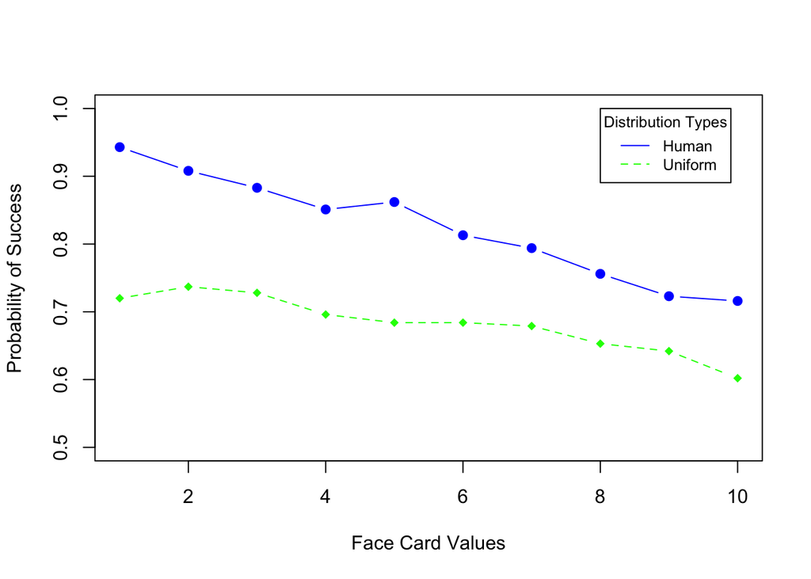

# Optimizations

We attempt to optimize both the mean card value as well as the sample deck size independently in order to maximize the probability of success. According to Grime’s paper, the probability of success can be represented by the probability function where $x$ is the mean card value and $N$ is the card deck sample size:

$$P(success) = 1-(\frac{x^2-1}{x^2})^N$$

## One-D Average Card Value Optimization

First we will start by optimizing the mean card value. We fix the sample card deck size to a standard 52 card deck.

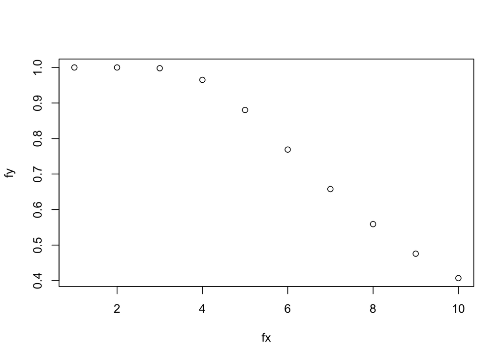

```r
#one dimension optimization of mean average card value
fx <- seq(1, 10, 1)
fy <- 1-((fx^2-1)/fx^2)^52
plot(fx, fy)
```

From the plot we see the maximum is achieved betwen the interval (1,4). Thus we run optim with those boundaries.

```r
success_function_standard_deck <- function(x) {
  1-((x^2-1)/x^2)^52
}
optim_average_card_val = optimize(success_function_standard_deck, lower=1, upper = 4, maximum = TRUE)$maximum
optim_average_card_val
```

```
## [1] 1.264
```

```r
optim_average_realistic_card_val = optimize(success_function_standard_deck, lower=4.46, upper = 10, maximum = TRUE)$maximum
optim_average_realistic_card_val
```

```
## [1] 4.46
```

We see now see that the maximizing mean card value is exactly the lower bound. This tells us the probability function is decreasing as the mean card value increases. This makes sense since the smaller variance among cards, the more likely the magician’s and participant’s card align, and thus leading to Kruskal algorithm converging early.

```r
calc_prob_success_human(100, 1) #mean = 4.46
```

```
## [1] 0.96
```

```r
calc_prob_success_human(100, 2) #mean = 4.69
```

```
## [1] 0.89
```

```r
calc_prob_success_human(100, 3) #mean = 4.92
```

```
## [1] 0.92
```

```r
calc_prob_success_human(100, 4) #mean = 5.15
```

```
## [1] 0.83
```

```r
calc_prob_success_human(100, 5) #mean = 5.38
```

```
## [1] 0.88
```

# One-D Average Card Deck Size Optimization

Now we will attempt to optimize on the sample size of the deck to maximize the probability of success.

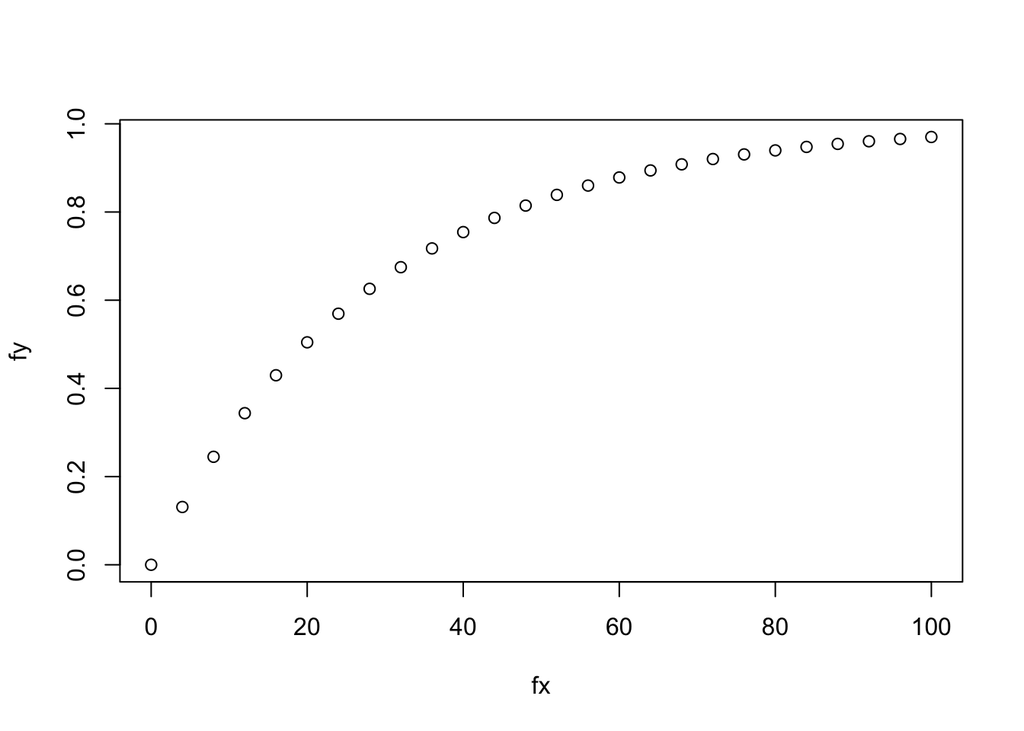

```r
default_card_mean_val = 5.384 #mean card value with face card values = 5
fx <- seq(0, 100, 4)
fy <- 1-((default_card_mean_val^2-1)/default_card_mean_val^2)^fx
plot(fx, fy)
```

We see that probability function given a fixed mean card value is increasingly asymptotic as the deck sample size increases.

```r
success_function_default_val_mean <- function(N) {
  x=default_card_mean_val
  1-((x^2-1)/x^2)^N
}
optim_deck_size = optimize(success_function_default_val_mean, lower = 0, upper = 100, maximum=TRUE)$maximum
optim_deck_size
```

```
## [1] 100
```

This is no surprise as the larger the sample size, the longer the two markov chains from the magician and participant have to achieve convergence before reaching the end. However, it is not truely optimum to continuously increase the sample deck size at the cost of run time. We can solve this by attempting to optimize on both variables and seeing the most desirable combination.

## Two-D Average Value and Sample Size Optimization

We use ‘optim’ to optimize both parameters(mean card value and sample deck size) of the probability success function. The prediction method we use is STATISTICA Automated Neural Networks (SANN) as it works for functions that does not guarantee to converge. SANN also utilizes a machine learning algorithm that can trim noisy outliers. Our initial input paramters is the lowest mean card value with face card values being 1 and 52 card standard deck.

```r
success_function <- function(input) {
  1-((input[1]^2-1)/input[1]^2)^input[2]
}
optim(c(4.46,52), success_function, method = "SANN")
```

```
## $par
## [1] 21.27 38.47
##
## $value
## [1] 0.0816
##
## $counts
## function gradient
##    10000       NA
##
## $convergence
## [1] 0
##
## $message
## NULL
```

# Simulation using card values assigned by the length of the card name.

Another variant mentioned in the research paper is if we used a modified hashmap with card values assigned by the length of the card name. For example, the Seven card would have a value of 5, Ace would have a value of 3, etc. This variation results in the highest probability we’ve seen so far, hovering around ~95%.

```r
# Create modified hashmap for card values
create_spelled_card_values <- function() {
  card_names = c("Ace", "Two", "Three", "Four", "Five", "Six", "Seven", "Eight", "Nine", "Ten", "Jack", "Queen", "King")
  num_cards = length(card_names)
  card_values = numeric(num_cards)
  for (i in 1:num_cards){
    card_values[i] = nchar(card_names[i])
  }
  hashmap(c("A",2:10,"J","Q","K"), card_values)
}

spelled_cards_map = create_spelled_card_values()

Face_Card_Value = seq(1, 10, 1) # Values of Face Cards to Test
Human_Prob = rep(0, 10) # Human Results
# Probability of Success Over 1-10 Values of Face Card with Uniform and Human Distribution
for(i in 1:10){
  Human_Prob[i] = calc_prob_success_human(1000, Face_Card_Value[i], rv_map_ = spelled_cards_map)
}

print(mean((Human_Prob))*100)
```

```
## [1] 95.63
```

# Appendix

## Data Source

The data used to simulate how humans would pick a random starting number from 1 to 10 was downloaded from this dataset from http://www.anondraw.com using a google form asking users to pick a random number between 1 and 10. https://docs.google.com/spreadsheets/d/1U-6LMy0AtfQB7MSjpNpVgQzVQXHuhJf50mkMTTms2a4/edit?usp=sharing

## Data Dictionary

Our data comes in the form of a single column of integer values from 1 to 10.

## Card Trick Information

http://www.ams.org/publicoutreach/feature-column/fcarc-mulcahy6 James Grime: http://singingbanana.com/